# Introducción a Programación lineal

La programación lineal es el campo de la optimización matemática dedicado a maximizar o minimizar (optimizar) una función lineal, denominada función objetivo, de tal forma que las variables de dicha función estén sujetas a una serie de restricciones expresadas mediante un sistema de ecuaciones o inecuaciones también lineales.

## Problemas de programación lineal expresados en **forma canonica**

[figure not shown]

https://en.wikipedia.org/wiki/Linear_programming

# Ejemplo gráfico:

## Problema

La compañia de Pepe diseña y vende dos tipos de anillos: **AA y TT**. La empresa puede producir hasta **24 anillos** cada día, usando como máximo un total de **60 h** de mano de obra. Le toma **3h un anillo AA** y **2h uno del tipo TT**, y además el beneficio por cada anillo **AA es $\$40$** y por anillo **TT es $\$30$** maximice el beneficio.

|  | Horas | Cantidad | Beneficio |
| --- | --- | --- | --- |
| Anillo AA | 3h | x | 40 |
| Anillo TT | 2h | y | 30 |

- Función beneficio(objetivo)

$$f(x,y) = 40x+30y$$

- Restricciones. $$ x+y\leq 24$$ $$3x+2y\leq 60$$ $$x\geq 0$$ $$y\geq 0$$

## Resolverlo de manera gráfica

- Generamos las lineas $$ x+y = 24$$ $$3x+2y = 60$$
- Despejando $$ y_1 = 24 -x$$ $$ y_2 = \frac{60-3x}{2} $$

```python
%matplotlib inline
import matplotlib.pylab as plt
import numpy as np
```

```python
x = np.arange(-1,25)
y1 = 24-x
y2 = (60-3*x)/2
f = lambda X,Y: 40*np.array(X)+30*np.array(Y)
```

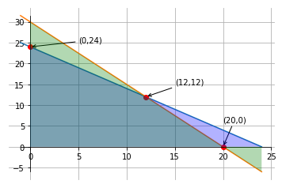

```python
fig = plt.figure()
ax = fig.gca()
ax.spines['left'].set_position('zero')
ax.spines['right'].set_color('none')
ax.spines['bottom'].set_position('zero')
ax.spines['top'].set_color('none')
ax.spines['left'].set_smart_bounds(True)
ax.spines['bottom'].set_smart_bounds(True)
ax.xaxis.set_ticks_position('bottom')
ax.yaxis.set_ticks_position('left')
ax.grid(True, zorder=5)

ax.plot(x,y1)
ax.plot(x,y2)
ax.fill_between(x,y1,where=x>=0,facecolor="blue",alpha=0.3,zorder=6 )
ax.fill_between(x,y2,where=x>=0,facecolor="green",alpha=0.3,zorder=7 )
ax.plot([0,12,20],[24,12,0],'ro')

ax.annotate("(0,24)", xy=(0, 24), xytext=(5, 25),
    arrowprops=dict(arrowstyle="->"))

ax.annotate("(12,12)", xy=(12, 12), xytext=(15, 15),
    arrowprops=dict(arrowstyle="->"))
ax.annotate("(20,0)", xy=(20, 0), xytext=(20, 6),
    arrowprops=dict(arrowstyle="->"))


plt.show()
```

### Las ecuaciones las ponemos de manera matricial

$$ x+y = 24$$ $$3x+2y = 60$$

```python
A=[ [1,1],[3,2]]
b=[24,60]
np.linalg.solve(A,b) ## Solucion de nuestro sistema
```

```
array([ 12.,  12.])
```

```python
# evaluamos todas las soluciones
f([0,12,20],[24,12,0])
# La mayor es f(12,12) = 840
```

```
array([720, 840, 800])
```

## Problema con tres variables es un poliedro convexo

[figure not shown]

# Algoritmo Simplex

El término algoritmo Símplex habitualmente se refiere a un conjunto de métodos muy usados para resolver problemas de programación lineal, en los cuales se busca el máximo de una función lineal sobre un conjunto de variables que satisfaga un conjunto de inecuaciones lineales.

[figure not shown]

donde **$x$** son las variables desde la forma estándar, **$x_s$** son las variables de holgura introducidas en el proceso de aumentación, **$c$** contiene los coeficientes de optimización, describe el sistema de ecuaciones contraídas, y **$z$** es la variable a ser maximizada.

Ejemplos en https://en.wikipedia.org/wiki/Simplex_algorithm

## Ejemplo 1

[figure not shown]

## Ejemplo 2

[figure not shown]

# Utilizando librerias de python

Generalizacion de problema de programación lineal (LP)

[figure not shown]

## Ejemplo

[figure not shown]

## Utilizando pulp

PuLP is a free open source software written in Python. It is used to describe optimisation problems as mathematical models. PuLP can then call any of numerous external LP solvers (CBC, GLPK, CPLEX, Gurobi etc) to solve this model and then use python commands to manipulate and display the solution.

https://pythonhosted.org/PuLP/main/installing_pulp_at_home.html#installation

- pip install pulp

```python
from pulp import *
```

```python
mi_lp_problema = pulp.LpProblem("Mi LP Problema", pulp.LpMinimize)

x = pulp.LpVariable('x',lowBound=0,cat='Continuous')
y = pulp.LpVariable('y',lowBound=0,cat='Continuous')

# Objective function
mi_lp_problema +=  x +  2*y

# Constraints
mi_lp_problema += 3*x + 4*y >= 1
mi_lp_problema += 2*x + 5*y >= 2
```

```python
mi_lp_problema
```

```
Mi LP Problema:
MINIMIZE
1*x + 2*y + 0
SUBJECT TO
_C1: 3 x + 4 y >= 1

_C2: 2 x + 5 y >= 2

VARIABLES
x Continuous
y Continuous
```

```python
mi_lp_problema.solve()
pulp.LpStatus[mi_lp_problema.status]
```

```
'Optimal'
```

[figure not shown]

```python
for variable in mi_lp_problema.variables():
    print("{} = {}".format(variable.name, variable.varValue))
```

```
x = 0.0
y = 0.4
```

```python
print(pulp.value(mi_lp_problema.objective))
```

```
0.8
```

## Utilizando pyomo

### Guía de instalación de Pyomo

https://github.com/CAChemE/pyomo-instalacion

- conda install pyomo -c conda-forge
- conda install pyomo.extras --channel conda-forge
- conda install glpk -c conda-forge
- conda install -c cachemeorg ipopt_bin

```python
from pyomo.environ import *
```

```python
m = ConcreteModel()

m.x_1 = Var(within=NonNegativeReals)
m.x_2 = Var(within=NonNegativeReals)

m.obj = Objective(expr= m.x_1 + 2*m.x_2, sense=minimize )

m.c1 = Constraint(expr= 3*m.x_1 + 4*m.x_2 >= 1)
m.c2 = Constraint(expr= 2*m.x_1 + 5*m.x_2 >= 2)

solver = SolverFactory('ipopt')
status = solver.solve(m)

print("Status = %s" % status.solver.termination_condition)

print("%s = %f" % (m.x_1, value(m.x_1)))
print("%s = %f" % (m.x_2, value(m.x_2)))
print("Objective = %f" % value(m.obj))
```

```
Status = optimal
x_1 = 0.000000
x_2 = 0.400000
Objective = 0.800000
```

## Utilizando cvxopt

- pip install cvxopt

[figure not shown]

```python
from cvxopt import matrix, solvers


A = matrix([ [-3.0, -2.0, -1.0, 0.0],
             [-4.0, -5.0, 0.0, -1.0] ])

b = matrix([ 1.0, -2.0, 0.0, 0.0 ])
c = matrix([ 1.0, 2.0 ])
sol=solvers.lp(c,A,b)

print(sol['x'])
```

```
     pcost       dcost       gap    pres   dres   k/t
 0:  3.2692e-01  1.3462e+00  8e+00  2e+00  5e+00  1e+00
 1:  9.1943e-01  9.3094e-01  1e+00  2e-01  7e-01  9e-03
 2:  8.0749e-01  8.1424e-01  3e-02  1e-02  4e-02  7e-03
 3:  8.0007e-01  8.0014e-01  3e-04  1e-04  4e-04  7e-05
 4:  8.0000e-01  8.0000e-01  3e-06  1e-06  4e-06  7e-07
 5:  8.0000e-01  8.0000e-01  3e-08  1e-08  4e-08  7e-09
Optimal solution found.
[ 5.45e-08]
[ 4.00e-01]
```

# Ejemplo

## Con Pulp

$$ \begin{array}{ll} \mbox{minimize} & 2x_1 + x_2 \\ \mbox{subject to} & -x_1 + x_2 \leq 1 \\ & x_1 + x_2 \geq 2 \\ & x_2 \geq 0 \\ & x_1 -2x_2 \leq 4 \end{array} $$

```python
# pulp
mi_lp_problema = pulp.LpProblem("Mi LP Problema", pulp.LpMinimize)

x = pulp.LpVariable('x',lowBound=0,cat='Continuous')
y = pulp.LpVariable('y',lowBound=0,cat='Continuous')

# Objective function
mi_lp_problema +=  2*x +  y

# Constraints
mi_lp_problema += -x + y <= 1
mi_lp_problema +=  x + y >= 2
mi_lp_problema +=  x - 2*y <= 4

mi_lp_problema.solve()
pulp.LpStatus[mi_lp_problema.status]

for variable in mi_lp_problema.variables():
    print("{} = {}".format(variable.name, variable.varValue))

print(pulp.value(mi_lp_problema.objective))
```

```
x = 0.5
y = 1.5
2.5
```

## Con Pyomo

$$ \begin{array}{ll} \mbox{minimize} & 2x_1 + x_2 \\ \mbox{subject to} & -x_1 + x_2 \leq 1 \\ & x_1 + x_2 \geq 2 \\ & x_2 \geq 0 \\ & x_1 -2x_2 \leq 4 \end{array} $$

```python
# pyomo
m = ConcreteModel()

m.x_1 = Var(within=NonNegativeReals)
m.x_2 = Var(within=NonNegativeReals)

m.obj = Objective(expr= 2*m.x_1 + m.x_2, sense=minimize )

m.c1 = Constraint(expr= -m.x_1 + m.x_2 <= 1)
m.c2 = Constraint(expr= m.x_1 + m.x_2 >= 2)
m.c3 = Constraint(expr= m.x_1 - 2*m.x_2 <= 4)

solver = SolverFactory('ipopt')
status = solver.solve(m)

print("Status = %s" % status.solver.termination_condition)

print("%s = %f" % (m.x_1, value(m.x_1)))
print("%s = %f" % (m.x_2, value(m.x_2)))
print("Objective = %f" % value(m.obj))
```

```
Status = optimal
x_1 = 0.500000
x_2 = 1.500000
Objective = 2.500000
```

## Con CVXOPT

$$ \begin{array}{ll} \mbox{minimize} & 2x_1 + x_2 \\ \mbox{subject to} & -x_1 + x_2 \leq 1 \\ & x_1 + x_2 \geq 2 \\ & x_2 \geq 0 \\ & x_1 -2x_2 \leq 4 \end{array} $$

```python
from cvxopt import matrix, solvers
A = matrix([ [-1.0, -1.0, 0.0, 1.0], [1.0, -1.0, -1.0, -2.0] ])
b = matrix([ 1.0, -2.0, 0.0, 4.0 ])
c = matrix([ 2.0, 1.0 ])
sol=solvers.lp(c,A,b)
```

```
     pcost       dcost       gap    pres   dres   k/t
 0:  2.6471e+00 -7.0588e-01  2e+01  8e-01  2e+00  1e+00
 1:  3.0726e+00  2.8437e+00  1e+00  1e-01  2e-01  3e-01
 2:  2.4891e+00  2.4808e+00  1e-01  1e-02  2e-02  5e-02
 3:  2.4999e+00  2.4998e+00  1e-03  1e-04  2e-04  5e-04
 4:  2.5000e+00  2.5000e+00  1e-05  1e-06  2e-06  5e-06
 5:  2.5000e+00  2.5000e+00  1e-07  1e-08  2e-08  5e-08
Optimal solution found.
```

```python
print("[x1,x2] = ",sol['x'].T)
print ("Objective ",sol['primal objective'])
```

```
[x1,x2] =  [ 5.00e-01  1.50e+00]

Objective  2.4999999895543077
```

"Cuaderno 2"

```python
!ls
```

```
ClasePL.ipynb
IntroPyomo.ipynb
PLEjemplos.ipynb
PrecioUmbral.ipynb
ProblemaDieta.ipynb
Pyomo-Diet-master
cachemetransporte.ipynb
diet.dat
how-to-improve-your-diet-and-save-money-with-python.zip
info.dat
transportation.dat
```